# Pol Sci 200D Notes: Refresher

Haotian (Barney) Chen

January 10, 2025

## OLS Refresher

In the classical regression model, we have the following assumptions:

- (A.1) **Linearity**: $\mathbf{Y}= \mathbf{X}\mathbb{\beta} + \epsilon$
- (A.2) **Strict Exogeneity**: $\mathbb{E}[\epsilon | \mathbf{X}] = 0$. The explanatory variables are exogenous (uncorrelated with the error term). It implies:
  - (A.2.a) Weak Exogeneity: $\mathbb{E}[\mathbf{X}_i\epsilon_i] = 0$. The explanatory variable is orthogonal to the error term.
  - (A.2.b) Unconditional Mean: $\mathbb{E}[\epsilon_i] = 0$. The error term has zero mean.
- (A.3) **Full Rank**: $\text{rank}(\mathbf{X})=k$ (we need $\mathbf{X}'\mathbf{X}$ to be invertible). A violation is *perfect multicollinearity* when some explanatory variables are linearly dependent.
- (A.4) Spherical Errors: $\mathbb{V}[\epsilon | \mathbf{X}] = \mathbb{E}[\epsilon\epsilon'|\mathbf{X}] = \sigma^2 I_n$. It implies:
  - (A.4.a) **Homoskedasticity**: $\mathbb{V}[\epsilon_i | \mathbf{X}] = \sigma^2$. Error terms have constant variance. No heteroskedasticity.
  - (A.4.b) **No Autocorrelation of Errors**: $\mathbb{Cov}[\epsilon_i, \epsilon_j | \mathbf{X}] = \mathbb{E}[\epsilon_i \epsilon_j | \mathbf{X}] = 0$ for $i \neq j$. No serial correlation.
- (A.5) **Normality**: $\epsilon | \mathbf{X}\sim N(0, \sigma^2I_n)$. The error terms are normally distributed.

Under these assumptions, we can estimate the OLS estimator $\hat{\beta} = (\mathbf{X}'\mathbf{X})^{-1}\mathbf{X}'Y$. Here are the properties of OLS Estimator:

- **Unbiasedness**: $\mathbb{E}[\hat{\beta} | \mathbf{X}] = \beta$.
- **Efficiency**: The Gauss–Markov theorem states that the OLS estimator is BLUE (Best Linear Unbiased Estimator).
- **Consistency**: $\hat{\beta} \xrightarrow{p} \beta$ as $n \rightarrow \infty$.
- **Asymptotically Normality**: $\hat{\beta} \sim N(\beta, \sigma^2 (\mathbf{X}'\mathbf{X})^{-1})$.

## Mathematics Refresher

This class assumes familiarity in probability theory and linear algebra. Check [Harvard’s Math Prefresher](https://iqss.github.io/prefresher/) if you need a refresher. Below I provide a quick review.

- **Prior Distribution**: the probability of the parameter $\theta$ before observing data, denoted as $\xi(\theta)$.
- **Posterior Distribution**: the conditional distribution of $\theta$ given observed data $X_1, X_2, \ldots, X_n$, denoted as $\xi(\theta | x_1, \ldots, x_n)$.
- **Likelihood Function**: $\xi(\theta | x_1, \ldots, x_n) \propto f_n(x_1, \ldots, x_n | \theta) \xi(\theta)$. Here the likelihood function is $L(\theta) = f_n(x_1, \ldots, x_n | \theta)$.
- Again: $\text{Posterior} \propto \text{Likelihood} \cdot \text{Prior}$
- **Conjugate Families**: choosing a conjugate prior that the posterior is in same family as the prior. We discuss three conjugate families: Normal-Normal, Beta-Binomial, and Gamma-Poisson.
  - Normal Prior, Normal Data:

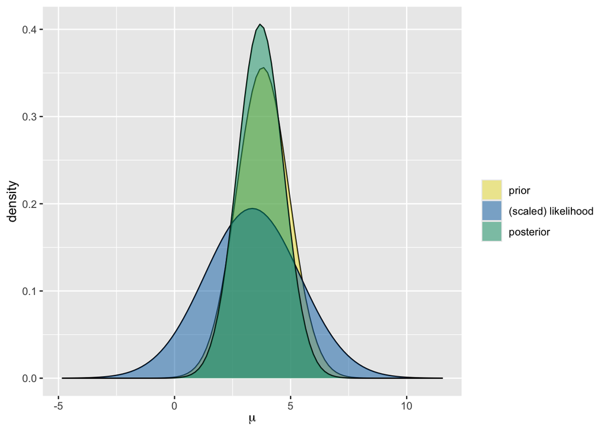

  - Beta Prior, Binomial Data:

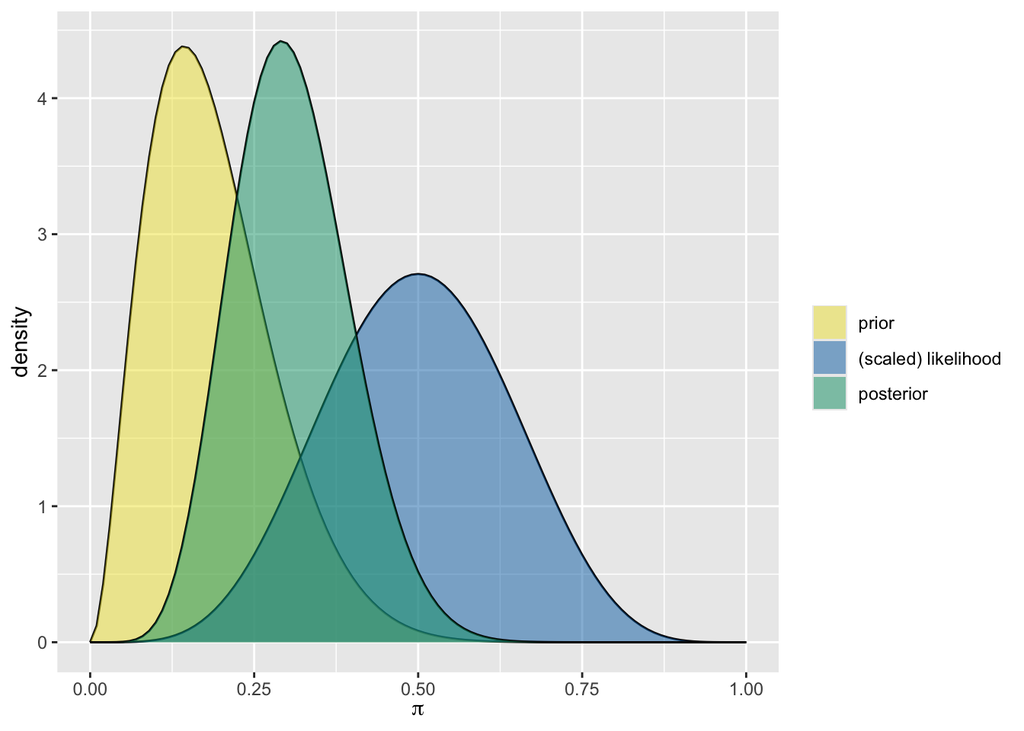

  - Gamma Prior, Poisson Data:

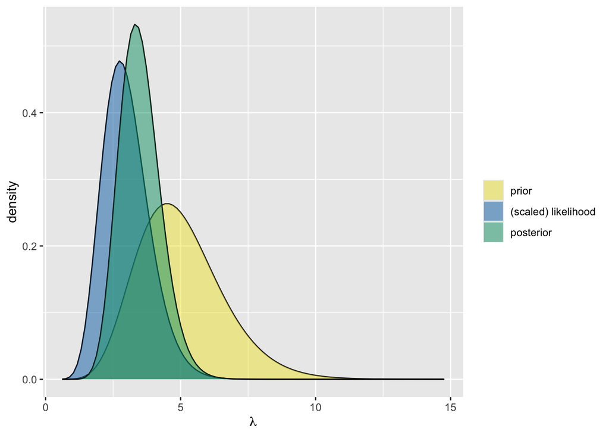

## Programming Refresher

We will use R programming language in this class and follow the [tidyverse coding style](https://style.tidyverse.org). We recommend RStudio but of course, you can pick your favorite IDE. You are expected to submit your problem sets and exams using Quarto – check this [link](https://quarto.org/docs/faq/rmarkdown.html) for switching from RMarkdown to Quarto. For any output you produce for this class, make sure the tables (e.g., using `gt()` or `kable()`) and figures (using `ggplot`) are well-formatted and easy to read.

### Simulation

Here is a quick review for Monte Carlo Simulation in R.

```r
# common distributions (prefix r-; for density, prefix d-; for cumulative, prefix p-)
rnorm() # Normal
runif() # Uniform
rbinom() # Binomial
rpois() # Poisson
rexp() # Exponential

# apply family functions
apply()
sapply()
lapply()
tapply()
```

```r
library(tidyverse)

# random seeds for reproducibility
set.seed(2025)

# sample() function
sample(x = 1:10, size = 6, replace = FALSE)
```

```
## [1] 4 1 7 6 3 2
```

```r
sample(x = 1:10, size = 6, replace = TRUE)
```

```
## [1] 1 4 7 5 7 5
```

```r
# replicate() function
replicate(3, rnorm(2))
```

```
##           [,1]       [,2]       [,3]
## [1,] 0.5689852 -0.8446397 -1.0643315
## [2,] 1.3944046 -0.6445391  0.1145143
```

```r
# map family functions (from purrr)
modtwo <- function(.x) {
  return(.x %% 2)
}

map(c(1, 8, 13, 20), modtwo) # apply modtwo() to each element in the vector
```

```
## [[1]]
## [1] 1
##
## [[2]]
## [1] 0
##
## [[3]]
## [1] 1
##
## [[4]]
## [1] 0
```

```r
map_df(c(1, 8, 13, 20), function(.x) {
  return(data.frame(number = .x,
                    mod2 = modtwo(.x)))
}) # apply modtwo() to each element in the vector and return a data frame
```

```
##   number mod2
## 1      1    1
## 2      8    0
## 3     13    1
## 4     20    0
```

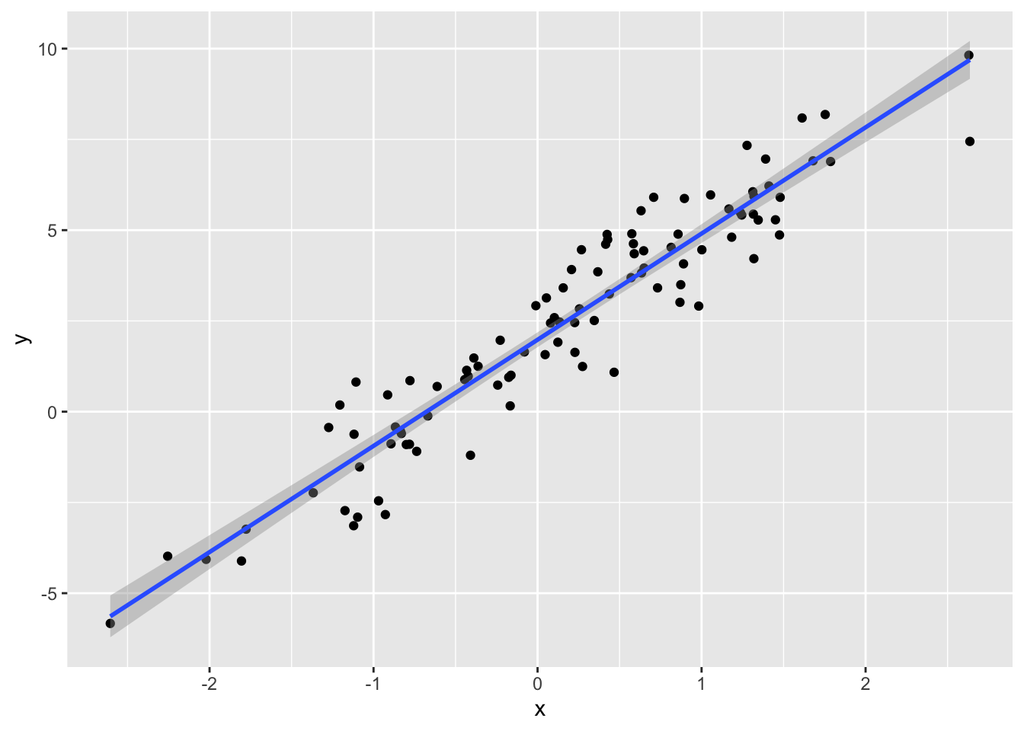

```r
# simulate a simple dataset using function()
simulate_lm <- function(n = 100, beta0 = 2, beta1 = 3) {
  x <- rnorm(n)
  y <- beta0 + beta1 * x + rnorm(n)
  return(data.frame(x = x, y = y))
}

data <- simulate_lm(100, 2, 3)

ggplot(data, aes(x = x, y = y)) +
  geom_point() +
  geom_smooth(method = "lm")
```